# The NBA - A 3 Point Driven League?

Mauro

May 12, 2018

# Introduction

The NBA has been around since 1946. Over the years, the play style has changed a bit. It has gone from a league where centers and power forwards primarily posted up, to a league where its normal for bigs to be able to shoot 3 pointers. 3 pointers are becoming a more and more prominent part of the game. In this data analysis, we will look at the change in frequency of 3 pointers being shot over the years and we will try to see if teams who are better at shooting 3 pointers tend to win more. This could be useful in helping teams decide if they should invest more of their money towards signing better 3 point shooters as opposed to better mid range shooters or post up players.

# Importing our data

```r
library(tidyverse)
nba_data <- read_csv("NBA_train.csv")
head(nba_data)
```

```
## # A tibble: 6 x 20
##   SeasonEnd Team       Playoffs     W   PTS oppPTS    FG   FGA  `2P` `2PA`
##       <int> <chr>         <int> <int> <int>  <int> <int> <int> <int> <int>
## 1      1980 Atlanta H~        1    50  8573   8334  3261  7027  3248  6952
## 2      1980 Boston Ce~        1    61  9303   8664  3617  7387  3455  6965
## 3      1980 Chicago B~        0    30  8813   9035  3362  6943  3292  6668
## 4      1980 Cleveland~        0    37  9360   9332  3811  8041  3775  7854
## 5      1980 Denver Nu~        0    30  8878   9240  3462  7470  3379  7215
## 6      1980 Detroit P~        0    16  8933   9609  3643  7596  3586  7377
## # ... with 10 more variables: `3P` <int>, `3PA` <int>, FT <int>,
## #   FTA <int>, ORB <int>, DRB <int>, AST <int>, STL <int>, BLK <int>,
## #   TOV <int>
```

# Preparing our data

Now that we have the data that we’re going to use, let’s clean it up a little so that our data frame is not cluttered with data that we won’t be using. For our analysis, we will only be using the SeasonEnd, Team, Playoffs, W, 3P, and 3PA columns. For this reason, we will drop all the other columns from the data frame. We can do this by making a vector with the names of the columns we want to keep and then reassigning the variable which holds our data frame to this new data frame with only the columns we need.

```r
to_keep <- c("SeasonEnd", "Team", "Playoffs", "W", "3P", "3PA")
nba_data <- nba_data[to_keep]
head(nba_data)
```

```
## # A tibble: 6 x 6
##   SeasonEnd Team                Playoffs     W  `3P` `3PA`
##       <int> <chr>                  <int> <int> <int> <int>
## 1      1980 Atlanta Hawks              1    50    13    75
## 2      1980 Boston Celtics             1    61   162   422
## 3      1980 Chicago Bulls              0    30    70   275
## 4      1980 Cleveland Cavaliers        0    37    36   187
## 5      1980 Denver Nuggets             0    30    83   255
## 6      1980 Detroit Pistons            0    16    57   219
```

Now that our data frame is less cluttered, we can add a column that we will need for our data analysis. We will add a column that we’ll name “3Pct”, which will hold the 3 point percentage for each team for a specific year. We calculate the 3pct column by dividing the 3P(3 pointers made) column by the 3PA(3 pointers attempted) column. If you are doing analysis in a sport where the number of games played per season has changed over the years, you would also have to calculate a win percentage column to account for possible inflation of wins because of more games being played. In this case, we will not need to do that because the NBA has been consistent with 82 game regular seasons since 1980. Columns are added to data frame by using the mutate function, as we can see below.

```r
nba_data <- nba_data %>%
  mutate("3Pct" = nba_data$`3P`/nba_data$`3PA`)
head(nba_data)
```

```
## # A tibble: 6 x 7
##   SeasonEnd Team                Playoffs     W  `3P` `3PA` `3Pct`
##       <int> <chr>                  <int> <int> <int> <int>  <dbl>
## 1      1980 Atlanta Hawks              1    50    13    75  0.173
## 2      1980 Boston Celtics             1    61   162   422  0.384
## 3      1980 Chicago Bulls              0    30    70   275  0.255
## 4      1980 Cleveland Cavaliers        0    37    36   187  0.193
## 5      1980 Denver Nuggets             0    30    83   255  0.325
## 6      1980 Detroit Pistons            0    16    57   219  0.260
```

One last adjustment to our data set we will have to do is change the column names of columns that start with a number. Column names that start with a number will cause a problem when trying to reference them while doing operations in our dataset. Additionally, “Year” seems like more of a fitting name than “SeasonEnd”. In order to change the column names, we will have to load a package called “data.table” and use the “set names” function from it.

```r
library(data.table)
nba_data %>%
  setnames(old = c('SeasonEnd','3P', '3PA','3Pct'), new = c('Year','ThreeP','ThreePA','ThreePct'))
head(nba_data)
```

```
## # A tibble: 6 x 7
##    Year Team                Playoffs     W ThreeP ThreePA ThreePct
##   <int> <chr>                  <int> <int>  <int>   <int>    <dbl>
## 1  1980 Atlanta Hawks              1    50     13      75    0.173
## 2  1980 Boston Celtics             1    61    162     422    0.384
## 3  1980 Chicago Bulls              0    30     70     275    0.255
## 4  1980 Cleveland Cavaliers        0    37     36     187    0.193
## 5  1980 Denver Nuggets             0    30     83     255    0.325
## 6  1980 Detroit Pistons            0    16     57     219    0.260
```

# Exploring our data

Now that we have the data we need, we will proceed to make some visualizations with it. The first thing we will do is see is see how the number of 3 pointers shot throughout the years has changed. In order to do this, we will need to group our data by Year by using the group_by function and then we use the summarize function to sum the amount of 3 point attempts for that specific year. In order to plot our data we use ggplot and specify the x value, y values, the type of plot we want to make “geom_col” in this case.

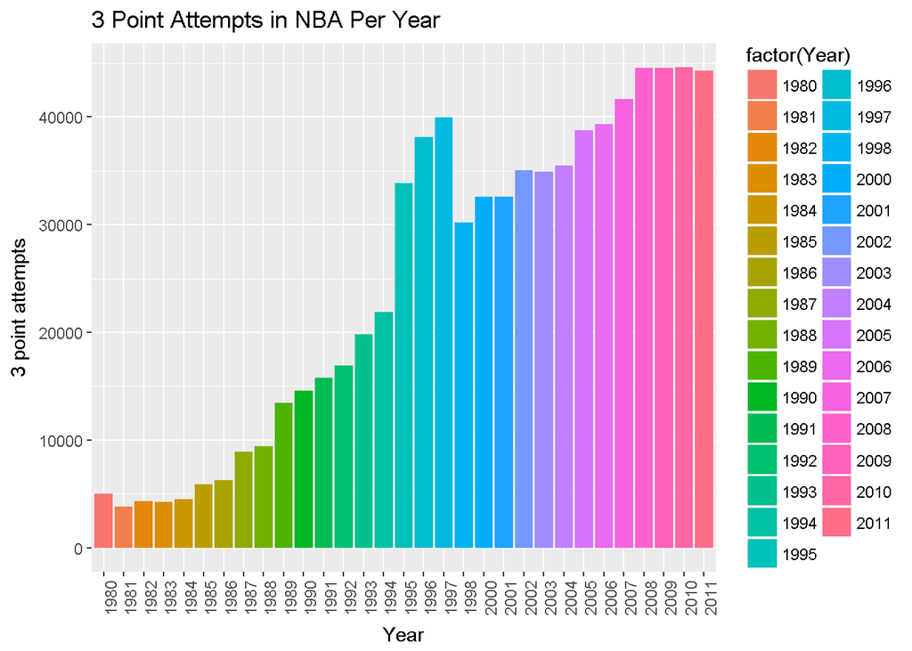

```r
nba_data%>%
  group_by(Year)%>%
  summarize(ThreeAttemptPerYear = sum(ThreePA))%>%
  ggplot(aes(x  = factor(Year), y = ThreeAttemptPerYear, fill = factor(Year))) + geom_col()+
  theme(axis.text.x = element_text(angle = 90, hjust = 1))+
  labs(x = "Year", y = "3 point attempts", title = "3 Point Attempts in NBA Per Year")
```

As we can see from the graph above, the number of 3 point attempts has steadily increased over the years as the game has changed. However, we do see a big spike in 3 point attempts during 1995, 1996, and 1997. This was not random, as it was the effect of the NBA making the 3 point line almost 2 feet shorter for those years. You can read more about this here https://clutchpoints.com/brief-time-90s-3-point-line-shorter/ .

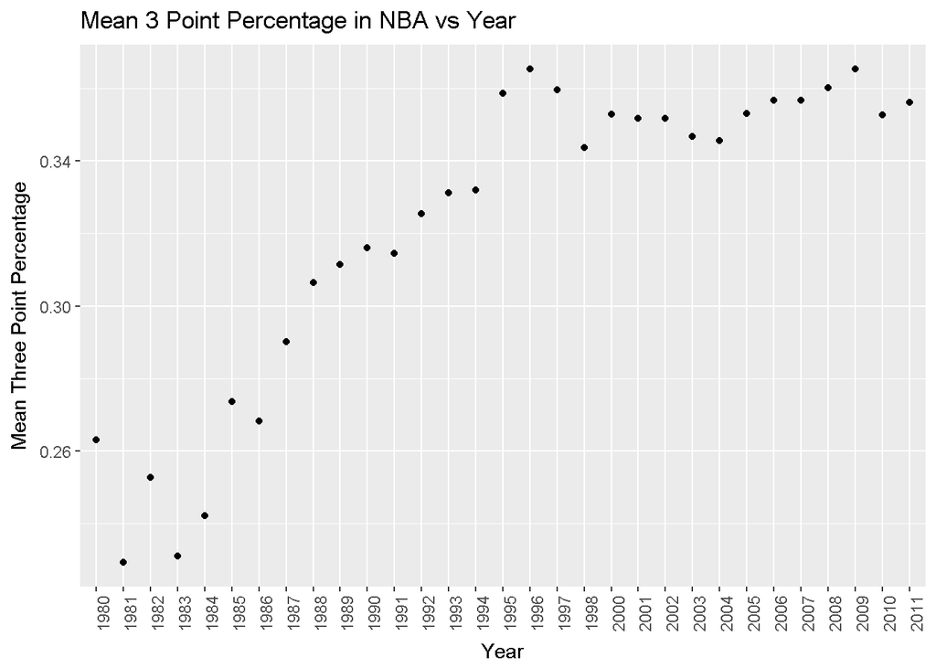

```r
nba_data %>%
  group_by(Year)%>%
  summarize(Mean3Pct = mean(ThreePct)) %>%
  ggplot(aes(x = factor(Year), y = Mean3Pct)) +geom_point()+
  theme(axis.text.x = element_text(angle = 90, hjust = 1))+
  labs(x = "Year", y = "Mean Three Point Percentage", title = "Mean 3 Point Percentage in NBA vs Year")
```

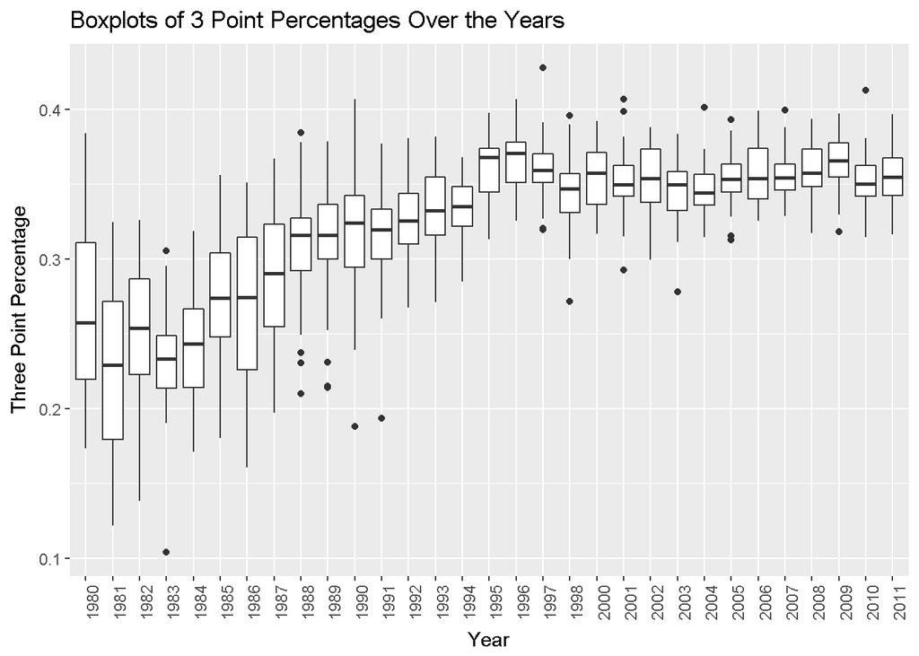

```r
nba_data%>%
  ggplot(aes(x = factor(Year), y = ThreePct)) + geom_boxplot(aes(group = Year))+
  theme(axis.text.x = element_text(angle = 90, hjust = 1))+
  labs(x = "Year", y = "Three Point Percentage", title = "Boxplots of 3 Point Percentages Over the Years")
```

From the scatter plot of mean 3 point shooting percentage, we can see that teams are not only shooting more 3 pointers but they are also becoming better at shooting them. Additionally, from the box plots of 3 point shooting percentages, it is evident that there is less of a disparity between the best and worst 3 point shooting teams in the league.

Now that we have seen how 3 point shooting has change over the years, we can start to focus on whether being a better 3 point shooting team necessarily equates to being a better team and winning more games. We’ll start off by just doing a general plot of number of games won vs 3 point percentage. Additionally, we will add a regression line.

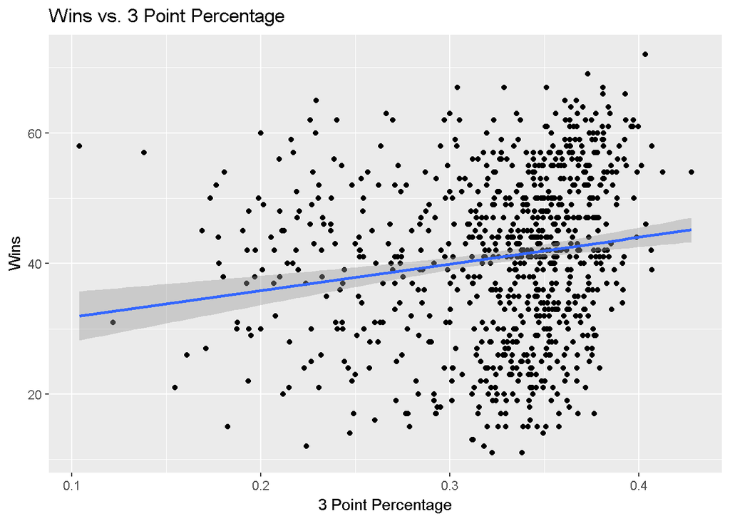

```r
nba_data%>%
  ggplot(aes(x = ThreePct, y =  W))+geom_point()+geom_smooth(method = lm) +
  labs(x = "3 Point Percentage", y = "Wins", title = "Wins vs. 3 Point Percentage")
```

From the regression line it seems that 3 point shooting percentage might play a small role in the number of games a team wins. However, this regression line is for all of the data at once. If we want to see how 3 point percentage has affected wins over smaller periods of time, we can use the cut function to breakup the data by years. We will break up the 31 years our data covers into 5 time periods.

```r
nba_time_periods = nba_data %>%
  mutate(Time_Period  =  cut(Year, breaks = 5))
head(nba_time_periods)
```

```
## # A tibble: 6 x 8
##    Year Team            Playoffs     W ThreeP ThreePA ThreePct Time_Period
##   <int> <chr>              <int> <int>  <int>   <int>    <dbl> <fct>
## 1  1980 Atlanta Hawks          1    50     13      75    0.173 (1980,1986]
## 2  1980 Boston Celtics         1    61    162     422    0.384 (1980,1986]
## 3  1980 Chicago Bulls          0    30     70     275    0.255 (1980,1986]
## 4  1980 Cleveland Cava~        0    37     36     187    0.193 (1980,1986]
## 5  1980 Denver Nuggets         0    30     83     255    0.325 (1980,1986]
## 6  1980 Detroit Pistons        0    16     57     219    0.260 (1980,1986]
```

Now that we have broken up our data into time periods, we can make individual Wins vs. 3 point percentage plots for each of them. We’ll do this by filtering our data frame by time period and then creating the plots. Well also store these filtered data frames, as we will use them later.

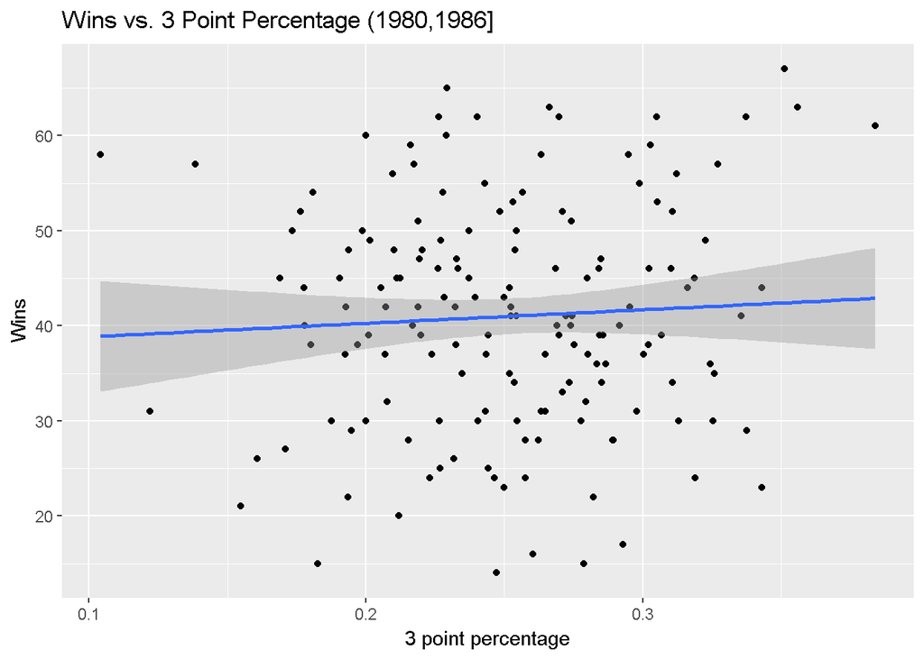

```r
nba_time_periods1986 <- nba_time_periods %>%
  filter(Time_Period=="(1980,1986]")

nba_time_periods1986%>%
  ggplot(aes(x = ThreePct, y = W))+geom_point() + geom_smooth(method = lm) +
  labs(x = "3 point percentage", y = "Wins", title = "Wins vs. 3 Point Percentage (1980,1986]")
```

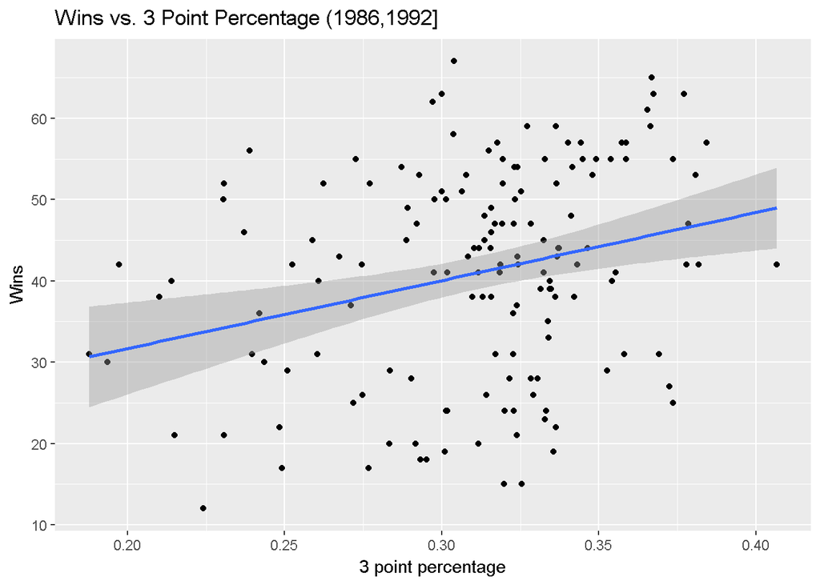

```r
nba_time_periods1992 <- nba_time_periods %>%
  filter(Time_Period=="(1986,1992]")

nba_time_periods1992%>%
  ggplot(aes(x = ThreePct, y = W))+geom_point() + geom_smooth(method = lm) +
  labs(x = "3 point percentage", y = "Wins", title = "Wins vs. 3 Point Percentage (1986,1992]")
```

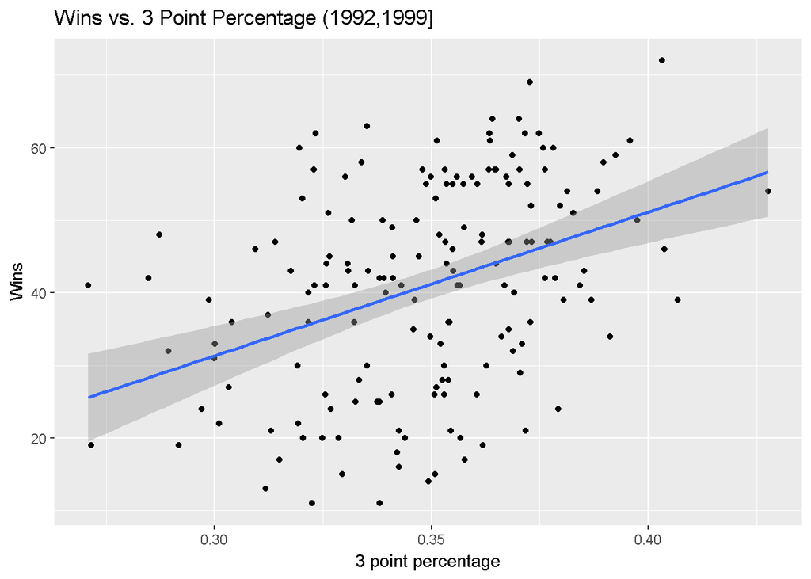

```r
nba_time_periods1999 <- nba_time_periods %>%
  filter(Time_Period=="(1992,1999]")

nba_time_periods1999%>%
  ggplot(aes(x = ThreePct, y = W))+geom_point() + geom_smooth(method = lm) +
  labs(x = "3 point percentage", y = "Wins", title = "Wins vs. 3 Point Percentage (1992,1999]")
```

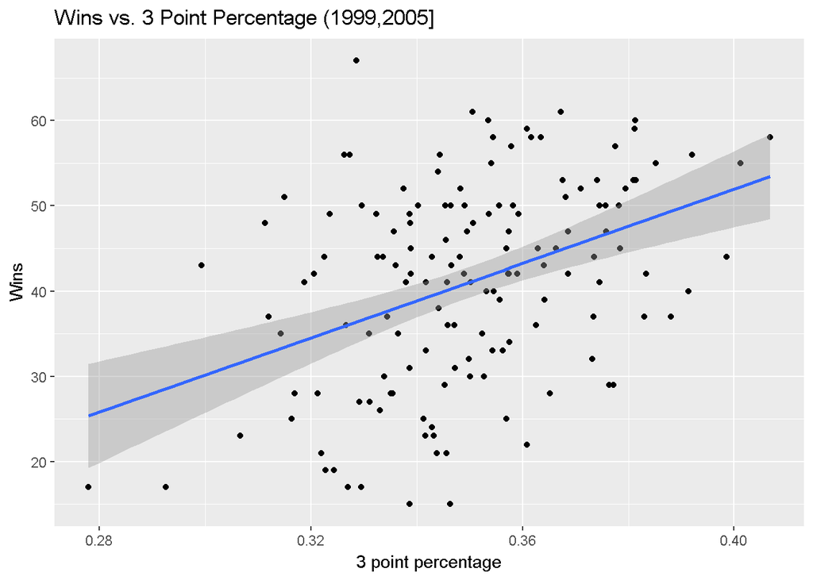

```r
nba_time_periods2005 <- nba_time_periods %>%
  filter(Time_Period=="(1999,2005]")

nba_time_periods2005%>%
  ggplot(aes(x = ThreePct, y = W))+geom_point() + geom_smooth(method = lm) +
  labs(x = "3 point percentage", y = "Wins", title = "Wins vs. 3 Point Percentage (1999,2005]")
```

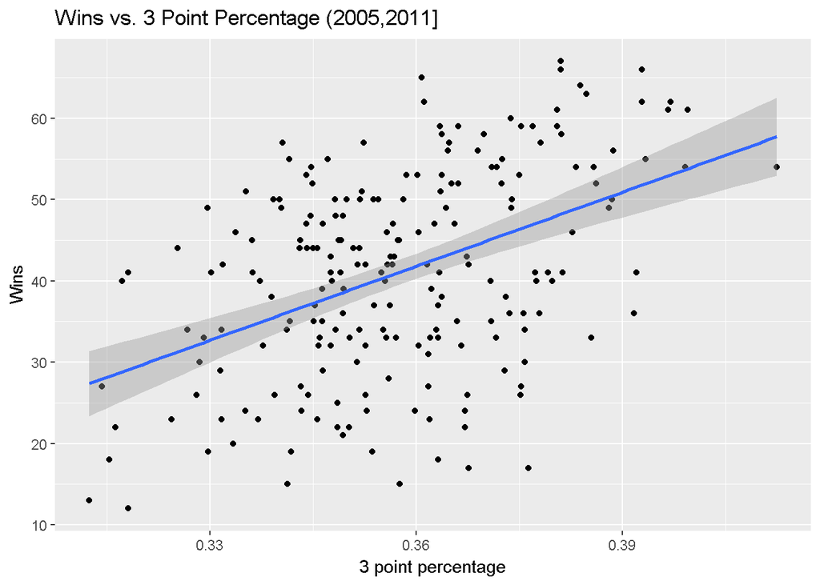

```r
nba_time_periods2011 <-nba_time_periods %>%
  filter(Time_Period=="(2005,2011]")

nba_time_periods2011%>%
  ggplot(aes(x = ThreePct, y = W))+geom_point() + geom_smooth(method = lm) +
  labs(x = "3 point percentage", y = "Wins", title = "Wins vs. 3 Point Percentage (2005,2011]")
```

Comparing successive graphs of the different time periods, it seems that the importance of 3 point percentage to number of wins has increased with each time period. In order to get a better sense for the linear regression lines, we’ll use the lm() function along with the tidy() function to create a linear model. In the lm function you will see “W~ThreePct”, which means we are making a linear model to predict wins based off of 3 point percentage. In the output, the estimate column of ThreePct is approximately the slope of the line we are looking at. Keep in mind that the x axis of our graphs only range a few hundredths so do not be alarmed if you see extremely high slopes. We’ll also do a linear model for our original data frame that contained all of our data.

```r
library(broom)
#Original data frame
lm(W~ThreePct, data = nba_data)%>%
  tidy()
```

```
##          term estimate std.error statistic      p.value
## 1 (Intercept) 27.75706  2.774068 10.005906 2.466088e-22
## 2    ThreePct 40.67095  8.414100  4.833666 1.595870e-06
```

```r
#(1980,1986])
lm(W~ThreePct, data = nba_time_periods1986)%>%
  tidy()
```

```
##          term estimate std.error statistic      p.value
## 1 (Intercept) 37.42765  4.880543 7.6687483 1.666933e-12
## 2    ThreePct 14.21180 19.050683 0.7459994 4.567763e-01
```

```r
#(1986,1992])
lm(W~ThreePct, data = nba_time_periods1992)%>%
  tidy()
```

```
##          term estimate std.error statistic      p.value
## 1 (Intercept) 14.96694  7.542374  1.984381 0.0490377333
## 2    ThreePct 83.61732 24.004124  3.483456 0.0006489535
```

```r
#(1992,1999])
lm(W~ThreePct, data = nba_time_periods1999)%>%
  tidy()
```

```
##          term estimate std.error statistic      p.value
## 1 (Intercept) -28.0289  12.99727 -2.156523 3.248203e-02
## 2    ThreePct 197.9342  37.15492  5.327267 3.206154e-07
```

```r
#(1999,2005])
lm(W~ThreePct, data = nba_time_periods2005)%>%
  tidy()
```

```
##          term  estimate std.error statistic      p.value
## 1 (Intercept) -35.15429  14.42591 -2.436886 1.604278e-02
## 2    ThreePct 217.74962  41.16630  5.289512 4.503347e-07
```

```r
#(2005,2011])
lm(W~ThreePct, data = nba_time_periods2011)%>%
  tidy()
```

```
##          term  estimate std.error statistic      p.value
## 1 (Intercept) -67.42804  14.92255 -4.518535 1.043663e-05
## 2    ThreePct 303.42170  41.70190  7.275969 6.908646e-12
```

From the linear models we constructed, we can see that that the slope has increased with each passing time period. If we had only looked at the linear model for the data as a whole and not broken it up into time periods, we would have underestimated or completely missed that 3 point shooting percentage is becoming more of a factor when it comes to winning games in the NBA.

While winning games is great, it doesn’t matter if you don’t make the playoffs. That’s why we’re now going to compare the 3 point shooting percentages of teams that don’t make the playoffs compared to the teams that do make the playoffs. We’ll make graphs for each of our time periods that shows he average 3 point shooting percentage of playoff teams and non playoff teams. We start with making the data frame we need. We group by Time Period and playoffs:

```r
summarized_playoffs<-nba_time_periods%>%
  group_by(Time_Period,Playoffs)%>%
  summarize(mean  = mean(ThreePct))
head(summarized_playoffs)
```

```
## # A tibble: 6 x 3
## # Groups:   Time_Period [3]
##   Time_Period Playoffs  mean
##   <fct>          <int> <dbl>
## 1 (1980,1986]        0 0.253
## 2 (1980,1986]        1 0.250
## 3 (1986,1992]        0 0.299
## 4 (1986,1992]        1 0.318
## 5 (1992,1999]        0 0.341
## 6 (1992,1999]        1 0.355
```

And now for the graphs, where 0 represents not making the playoffs and 1 represents making the playoffs:

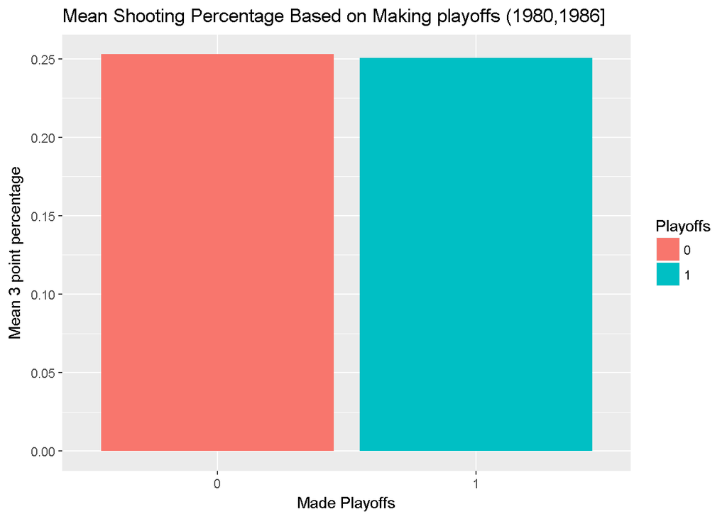

```r
summarized_playoffs %>%
  filter(Time_Period == "(1980,1986]")%>%
  ggplot(aes(x = factor(Playoffs), y = mean, fill = factor(Playoffs)))+geom_col()+
  scale_y_continuous(breaks=seq(0,.4,.05))+
  labs(x = "Made Playoffs", y = "Mean 3 point percentage", title = "Mean Shooting Percentage Based on Making playoffs (1980,1986]")+
  scale_fill_discrete(name = "Playoffs")
```

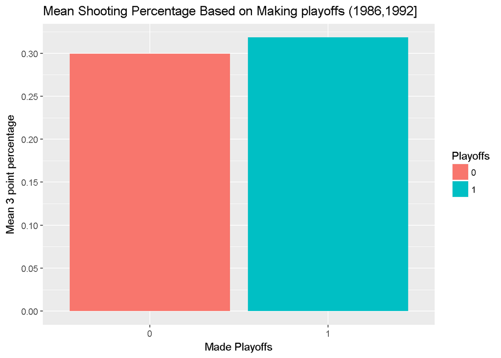

```r
summarized_playoffs %>%
  filter(Time_Period == "(1986,1992]")%>%
  ggplot(aes(x = factor(Playoffs), y = mean, fill = factor(Playoffs)))+geom_col()+
  scale_y_continuous(breaks=seq(0,.4,.05))+
  labs(x = "Made Playoffs", y = "Mean 3 point percentage", title = "Mean Shooting Percentage Based on Making playoffs (1986,1992]")+
  scale_fill_discrete(name = "Playoffs")
```

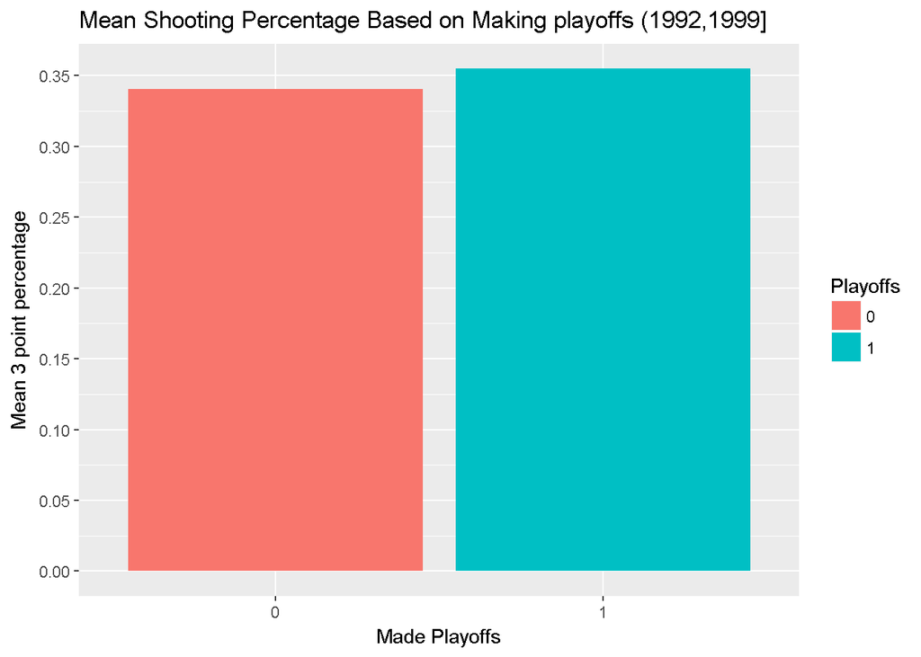

```r
summarized_playoffs %>%
  filter(Time_Period == "(1992,1999]")%>%
  ggplot(aes(x = factor(Playoffs), y = mean, fill = factor(Playoffs)))+geom_col()+
  scale_y_continuous(breaks=seq(0,.4,.05))+
  labs(x = "Made Playoffs", y = "Mean 3 point percentage", title = "Mean Shooting Percentage Based on Making playoffs (1992,1999]")+
  scale_fill_discrete(name = "Playoffs")
```

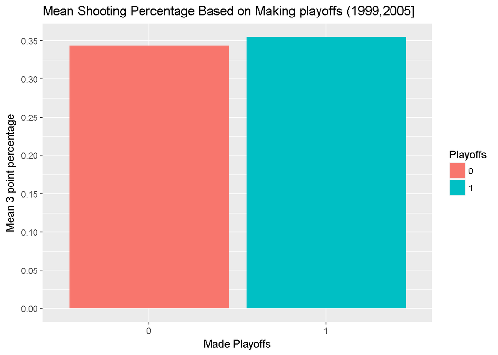

```r
summarized_playoffs %>%
  filter(Time_Period == "(1999,2005]")%>%
  ggplot(aes(x = factor(Playoffs), y = mean, fill = factor(Playoffs)))+geom_col()+
  scale_y_continuous(breaks=seq(0,.4,.05))+
  labs(x = "Made Playoffs", y = "Mean 3 point percentage", title = "Mean Shooting Percentage Based on Making playoffs (1999,2005]")+
  scale_fill_discrete(name = "Playoffs")
```

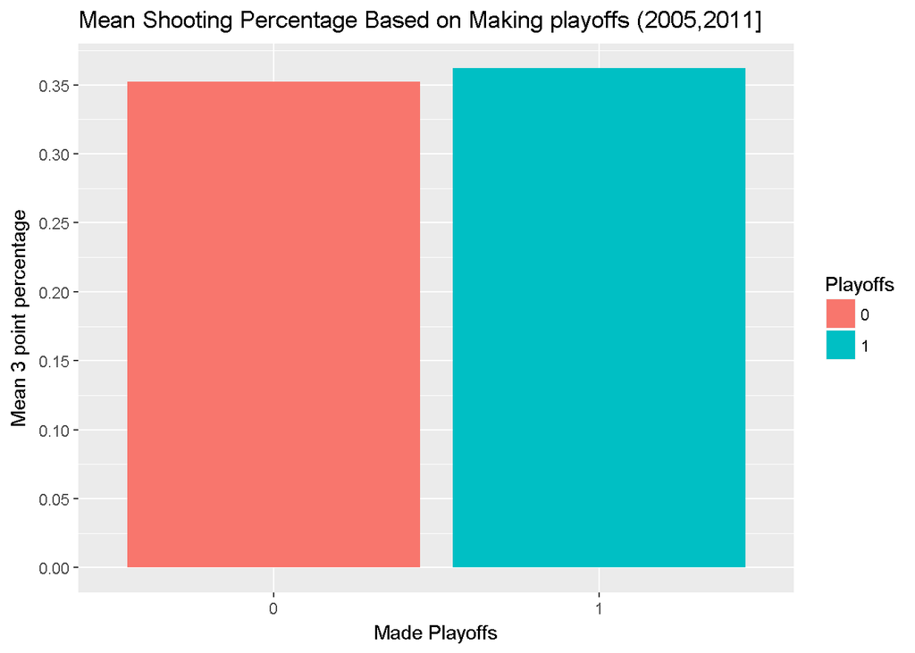

```r
summarized_playoffs %>%
  filter(Time_Period == "(2005,2011]")%>%
  ggplot(aes(x = factor(Playoffs), y = mean, fill = factor(Playoffs)))+geom_col()+
  scale_y_continuous(breaks=seq(0,.4,.05))+
  labs(x = "Made Playoffs", y = "Mean 3 point percentage", title = "Mean Shooting Percentage Based on Making playoffs (2005,2011]")+
  scale_fill_discrete(name = "Playoffs")
```

From looking at these graphs, you would actually think that over the years, 3 point shooting percentage hasn’t made much of a difference in teams making the playoffs, if any. However, this is only because teams have become better at 3 point shooting overall, thus the difference in percentages between playoff teams and non playoff teams has actually decreased. One way we could account for the overall improvement of 3 point shooting over the years is by standardizing 3 point shooting percentages based on the mean and standard deviation of 3 point shooting percentages for each time period. Then, we can calculate the mean standardized shooting percentage for each time period for playoff and non playoff teams and graphing that difference in absolute values. We do this below.

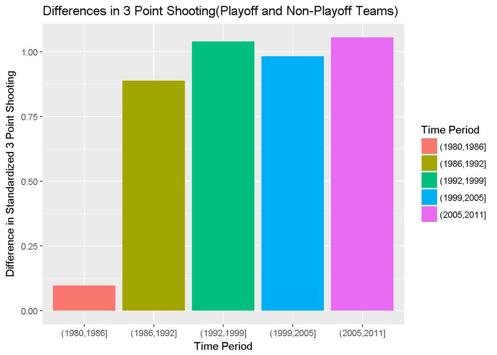

```r
#standardizing
stand_playoffs <- nba_time_periods%>%
 group_by(Time_Period)%>%
 mutate(standardized_three_pct = ((ThreePct-mean(ThreePct))/sd(ThreePct)))

#calculating mean standardized three point percentage for each time period
stand_summarized_playoffs <- stand_playoffs%>%
  group_by(Time_Period, Playoffs)%>%
  summarize(stan_mean_three_pct = mean(standardized_three_pct))

#calculating differences
stand_summarized_playoffs <- stand_summarized_playoffs%>%
  group_by(Time_Period)%>%
  mutate(differences = abs(diff(stan_mean_three_pct)))

stand_summarized_playoffs%>%
  ggplot(aes(x = Time_Period, y = differences, fill = Time_Period))+geom_col()+
  labs(x = "Time Period", y = "Difference in Standardized 3 Point Shooting", title = "Differences in 3 Point Shooting(Playoff and Non-Playoff Teams)")+
  scale_fill_discrete(name = "Time Period")
```

From the graph above, we can see that the standardized difference in 3 point shooting percentage between playoff and non playoff teams has actually increased over the years. It appears that there was very little difference between playoff and non playoff teams in (1980,1986]. This is consistent with our graphs above considering non playoff teams actually had a slightly better 3 point shooting percentage than playoff teams in that time period.

# Hypothesis Testing.

```r
#playoffs and 3 point shooting percentage
cor.test(nba_time_periods2011$Playoffs, nba_time_periods2011$ThreePct)
```

```
##
##  Pearson's product-moment correlation
##
## data:  nba_time_periods2011$Playoffs and nba_time_periods2011$ThreePct
## t = 3.9474, df = 208, p-value = 0.0001081
## alternative hypothesis: true correlation is not equal to 0
## 95 percent confidence interval:
##  0.1333677 0.3855997
## sample estimates:
##       cor
## 0.2639913
```

```r
cor.test(nba_time_periods2011$W, nba_time_periods2011$ThreePct)
```

```
##
##  Pearson's product-moment correlation
##
## data:  nba_time_periods2011$W and nba_time_periods2011$ThreePct
## t = 7.276, df = 208, p-value = 6.909e-12
## alternative hypothesis: true correlation is not equal to 0
## 95 percent confidence interval:
##  0.3354920 0.5521423
## sample estimates:
##       cor
## 0.4504232
```

Given that the p-value is so low for both of the test above, we can safely say that there is a statistically significant positive correlation between 3 point shooting percentage and both number of games won and making the playoffs.

# Conclusion

From the information above we do see that the NBA has changed quite a bit when it comes to not only the amount of 3 pointers being shot, but also the efficiency with which they are shot. We have also seen how the correlation has grown between 3 point shooting percentage and winning games and making the playoffs. As an avid watcher of the NBA, I believe that this trend has continued to grow even more since 2011. Unfortunately, more recent data was not available. In any case, it is quite clear that teams should invest in better 3 point shooters, even in positions where 3 point shooting hasn’t traditionally been emphasized, such as power forwards and centers.